# Eddie Module on Nutrient Loading

Note this is essentially the same thing as the water quality module and I think there is an issue with the set up as it is not correct

# Install the basic libraries

```r
# install.packages("tidyverse")
# install.packages("readxl")
# install.packages("janitor")
# install.packages("lubridate")
# install.packages("broom")
# install.packages("patchwork")
# install.packages("skimr")
```

# Load libraries

Load the libraries each time you run a script or program

```r
library(tidyverse) # loads a lot of libraries in this one to add more functionality
library(readxl) # allows you to read in excel files
library(janitor) # cleans up column names and removes empty columns if wanted
library(lubridate) # allows easy conversion of varaibles to date format
library(broom) # cleans up output for easy presentation
library(patchwork)
library(skimr)
```

# Read in files

Decar River in Palo Iowa 15 minute data

```r
decar.df <- read_excel("../data/nutrient_loading_module_data.xlsx",
                    sheet = "decar_river_palo_iowa")
```

# Recalculate columns for reproducibility

The conversion of cubic feet per second to liters required CFS to be multiplied by 28.136

```r
decar.df <- decar.df %>%
  mutate(time_int_load_kgn = discharge_cfs * nitrate_n_mgl * 28.136 * 15 * (60/1000000),
         time_int__q_l = discharge_cfs *28.136*15*60)
```

# Make a few new columns to help sample

To be able to resample the data we need to specify several different grouping varaibles to facilitate the grouping

```r
decar.df <- decar.df %>%
  mutate(
    date = as.Date(datetime),
    year = year(datetime),
    month = month(datetime),
    day =   day(datetime),
    week = week(datetime),
    month_year = paste(year,month, sep="/"),
    week_year  = paste(year,week, sep="/")
  )
```

# Plot of all data

This is just a plot of all of the data every 15 minutes

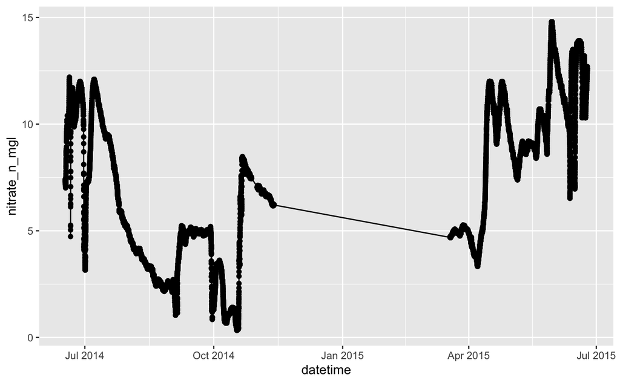

```r
decar.df %>%
  ggplot(aes(datetime, nitrate_n_mgl)) +
  geom_line()+
  geom_point()
```

# Resample to 4X daily

So we can use the date only grouping varaible to then sample 4 values from each date. The key for reporducible data here is to use a set.seed(some number) each time you run sample. Doing this randomly samples the data. The key is that this random number table used is repeatable using the seed #. You can change this number and then change it back and you will get the same samples t the next time.

```r
set.seed(134)

day_4x.df <- decar.df %>%
  filter(!is.na(nitrate_n_mgl)) %>%
  group_by(date) %>%
  sample_n(size=4, replace = FALSE)
```

# Plot of 4X daily data

This is the plot of the 4X per day.

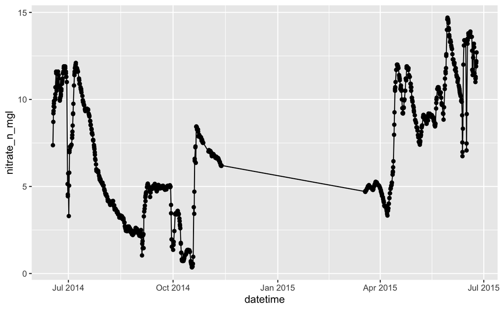

```r
day_4x.df %>%
  ggplot(aes(datetime, nitrate_n_mgl)) +
  geom_line()+
  geom_point()
```

# Daily resampling

This is the daily sampling of the data using the same seed.

```r
set.seed(134)

daily.df <- decar.df %>%
  filter(!is.na(nitrate_n_mgl)) %>%
  group_by(date) %>%
  sample_n(size=1, replace = FALSE)
```

# Daily resampling graph

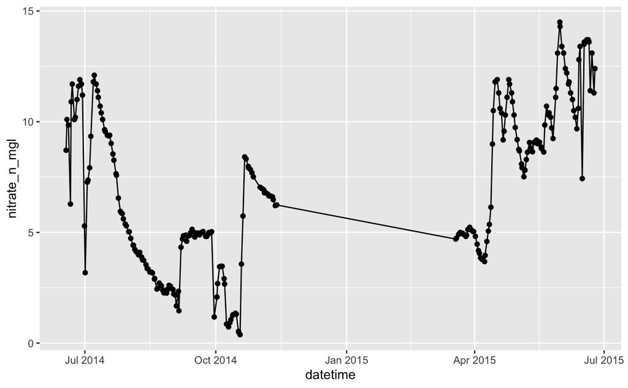

```r
daily.df %>%
  ggplot(aes(datetime, nitrate_n_mgl)) +
  geom_line()+
  geom_point()
```

# Weekly resampling

```r
set.seed(134)

weekly.df <- decar.df %>%
  filter(!is.na(nitrate_n_mgl)) %>%
  group_by(week_year) %>%
  sample_n(size=1, replace = FALSE)
```

# Weekly resampling graph of data

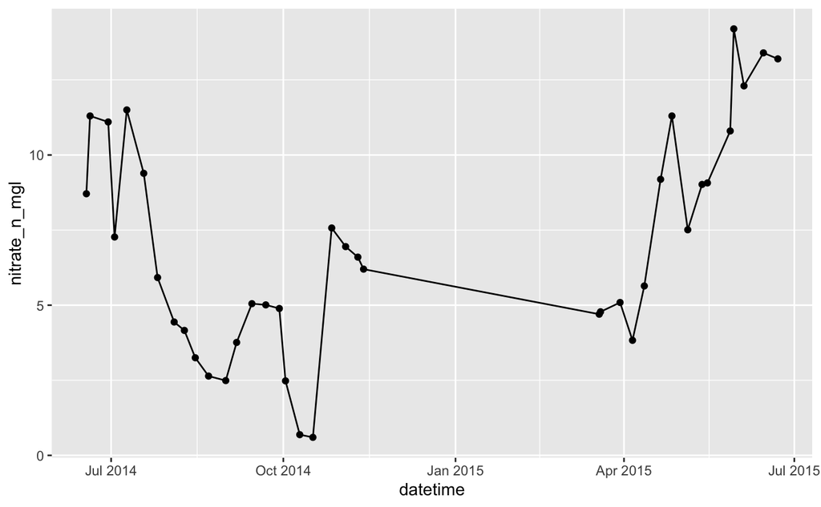

```r
weekly.df %>%
  ggplot(aes(datetime, nitrate_n_mgl)) +
  geom_line()+
  geom_point()
```

# Monthly resampling of data

```r
set.seed(134)

monthly.df <- decar.df %>%
  filter(!is.na(nitrate_n_mgl)) %>%
  group_by(month_year) %>%
  sample_n(size=1, replace = FALSE)
```

# Monthly resampling data graphs

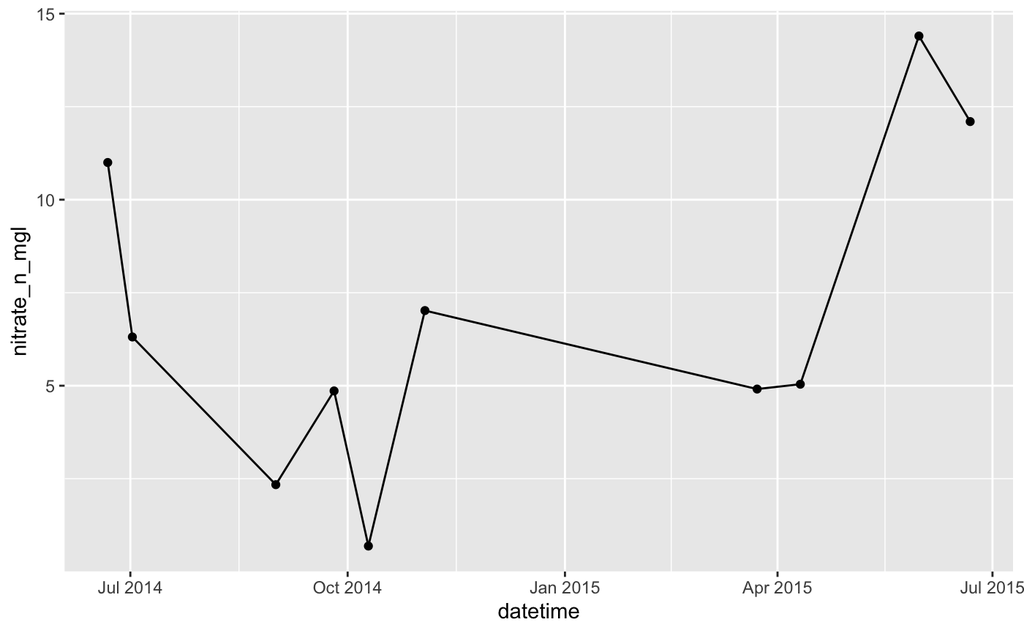

```r
monthly.df %>%
  ggplot(aes(datetime, nitrate_n_mgl)) +
  geom_line()+
  geom_point()
```

# Note this coudl be streamlined into all one

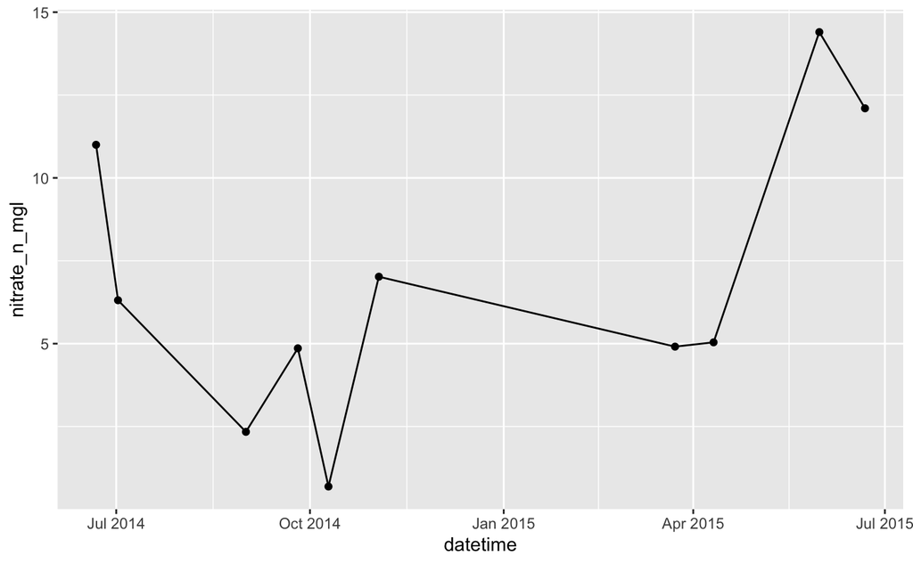

```r
# Monthly resampling of data

set.seed(134)

decar.df %>%
  filter(!is.na(nitrate_n_mgl)) %>%
  group_by(month_year) %>%
  sample_n(size=1, replace = FALSE) %>%
  ggplot(aes(datetime, nitrate_n_mgl)) +
  geom_line()+
  geom_point()
```

[output not shown]